# Taller PCA — DESPUÉS de las correcciones

8 variables · YJ selectivo · depuración de atípicos multivariados — Coffee Quality Institute

Juan Sebastián Guayazán · Esteban Valente · Diego Nocua

17 de noviembre de 2026

> **Propósito de este documento:** análisis corregido con tres ajustes metodológicos. (1) Se excluyen `Category.One.Defects`, `Category.Two.Defects` y `Moisture` (inflación de ceros, no normalizables). (2) Yeo-Johnson se aplica **solo** a variables con sesgo fuerte (|skewness| > 1) — las que ya son aproximadamente simétricas se dejan sin transformar para no introducir distorsiones innecesarias. (3) Se detectan atípicos multivariados por distancia de Mahalanobis vía scores del PCA exploratorio, se caracteriza qué tienen en común, se reporta su retiro y el PCA final corre sobre los datos depurados.

> **Notación del curso.** $X$: matriz $n \times p$; $\bar{x}$: media por columna; $P = I_n - \frac{1}{n}\mathbf{1}\mathbf{1}^\top$: centrado; $S = \frac{1}{n}\tilde{X}^\top\tilde{X}$: covarianza; $R = D^{-1/2}SD^{-1/2}$: correlación. `pca$rotation` = $A$ (vectores propios); `pca$x` = $Z = X^*A$ (scores).

# 1. Objetivo

Comparar cuatro métodos de reducción de dimensionalidad — **PCA**, **Kernel PCA**, **t-SNE** y **UMAP** — sobre 1.070 lotes de café arábica, respondiendo:

> ¿Qué información intenta preservar cada método y qué se puede interpretar a partir de la representación obtenida?

# 2. Datos

```r
library(dplyr)

data <- read.csv("../data/arabica_data_cleaned.csv")

vars_cuantitativas <- c("Aroma", "Flavor", "Aftertaste", "Acidity", "Body",
                         "Balance", "Uniformity", "Clean.Cup", "Sweetness",
                         "Cupper.Points", "Moisture", "Category.One.Defects",
                         "Category.Two.Defects", "altitude_mean_meters")

data_f <- data %>%
  filter(is.na(altitude_mean_meters) | (altitude_mean_meters > 0 & altitude_mean_meters <= 3000)) %>%
  filter(!is.na(altitude_mean_meters))

datos <- data_f %>% select(all_of(vars_cuantitativas))
```

Tras el tratamiento: **1070 observaciones**, **14 variables** de partida.

# 3. Exploración inicial

> **Teoría.** Todo el análisis multivariado parte de una matriz $X_{n \times p}$ con $n = 1070$ filas (lotes) y $p$ columnas (variables).

```r
str(datos)
```

```
## 'data.frame':    1070 obs. of  14 variables:
##  $ Aroma               : num  8.67 8.75 8.42 8.17 8.25 8.25 8.67 8.08 8.17 8.25 ...
##  $ Flavor              : num  8.83 8.67 8.5 8.58 8.5 8.33 8.67 8.58 8.67 8.42 ...
##  $ Aftertaste          : num  8.67 8.5 8.42 8.42 8.25 8.5 8.58 8.5 8.25 8.17 ...
##  $ Acidity             : num  8.75 8.58 8.42 8.42 8.5 8.42 8.42 8.5 8.5 8.33 ...
##  $ Body                : num  8.5 8.42 8.33 8.5 8.42 8.33 8.33 7.67 7.75 8.08 ...
##  $ Balance             : num  8.42 8.42 8.42 8.25 8.33 8.5 8.42 8.42 8.17 8.17 ...
##  $ Uniformity          : num  10 10 10 10 10 10 9.33 10 10 10 ...
##  $ Clean.Cup           : num  10 10 10 10 10 10 10 10 10 10 ...
##  $ Sweetness           : num  10 10 10 10 10 9.33 9.33 10 10 10 ...
##  $ Cupper.Points       : num  8.75 8.58 9.25 8.67 8.58 9 8.67 8.5 8.58 8.5 ...
##  $ Moisture            : num  0.12 0.12 0 0.11 0.12 0.03 0.03 0.1 0.1 0 ...
##  $ Category.One.Defects: int  0 0 0 0 0 0 0 0 0 0 ...
##  $ Category.Two.Defects: int  0 1 0 2 2 0 0 4 1 0 ...
##  $ altitude_mean_meters: num  2075 2075 1700 2000 2075 ...
```

```r
dim(datos)
```

```
## [1] 1070   14
```

```r
summary(datos)
```

```
##      Aroma          Flavor        Aftertaste       Acidity           Body
##  Min.   :0.00   Min.   :0.000   Min.   :0.000   Min.   :0.000   Min.   :0.000
##  1st Qu.:7.42   1st Qu.:7.330   1st Qu.:7.250   1st Qu.:7.330   1st Qu.:7.330
##  Median :7.58   Median :7.540   Median :7.420   Median :7.500   Median :7.500
##  Mean   :7.57   Mean   :7.518   Mean   :7.391   Mean   :7.527   Mean   :7.505
##  3rd Qu.:7.75   3rd Qu.:7.750   3rd Qu.:7.580   3rd Qu.:7.750   3rd Qu.:7.670
##  Max.   :8.75   Max.   :8.830   Max.   :8.670   Max.   :8.750   Max.   :8.580
##     Balance        Uniformity       Clean.Cup        Sweetness
##  Min.   :0.000   Min.   : 0.000   Min.   : 0.000   Min.   : 0.000
##  1st Qu.:7.330   1st Qu.:10.000   1st Qu.:10.000   1st Qu.:10.000
##  Median :7.500   Median :10.000   Median :10.000   Median :10.000
##  Mean   :7.507   Mean   : 9.866   Mean   : 9.847   Mean   : 9.923
##  3rd Qu.:7.750   3rd Qu.:10.000   3rd Qu.:10.000   3rd Qu.:10.000
##  Max.   :8.750   Max.   :10.000   Max.   :10.000   Max.   :10.000
##  Cupper.Points       Moisture       Category.One.Defects Category.Two.Defects
##  Min.   : 0.000   Min.   :0.00000   Min.   : 0.0000      Min.   : 0.000
##  1st Qu.: 7.250   1st Qu.:0.10000   1st Qu.: 0.0000      1st Qu.: 0.000
##  Median : 7.500   Median :0.11000   Median : 0.0000      Median : 2.000
##  Mean   : 7.485   Mean   :0.09298   Mean   : 0.3748      Mean   : 3.555
##  3rd Qu.: 7.750   3rd Qu.:0.12000   3rd Qu.: 0.0000      3rd Qu.: 4.000
##  Max.   :10.000   Max.   :0.20000   Max.   :31.0000      Max.   :47.000
##  altitude_mean_meters
##  Min.   :   1
##  1st Qu.:1100
##  Median :1311
##  Mean   :1304
##  3rd Qu.:1600
##  Max.   :2560
```

```r
colSums(is.na(datos))
```

```
##                Aroma               Flavor           Aftertaste
##                    0                    0                    0
##              Acidity                 Body              Balance
##                    0                    0                    0
##           Uniformity            Clean.Cup            Sweetness
##                    0                    0                    0
##        Cupper.Points             Moisture Category.One.Defects
##                    0                    0                    0
## Category.Two.Defects altitude_mean_meters
##                    0                    0
```

```r
cor(datos)
```

```
##                            Aroma      Flavor  Aftertaste    Acidity        Body
## Aroma                 1.00000000  0.83243132  0.79035860  0.7509512  0.73430681
## Flavor                0.83243132  1.00000000  0.89691922  0.8397081  0.80018756
## Aftertaste            0.79035860  0.89691922  1.00000000  0.8005331  0.79859904
## Acidity               0.75095124  0.83970808  0.80053314  1.0000000  0.77084371
## Body                  0.73430681  0.80018756  0.79859904  0.7708437  1.00000000
## Balance               0.73940862  0.82022183  0.83039478  0.7532019  0.80450346
## Uniformity            0.42558206  0.46236098  0.46864839  0.4532603  0.43810077
## Clean.Cup             0.37586702  0.44303524  0.44730896  0.3498741  0.34337325
## Sweetness             0.40659141  0.44361996  0.43875700  0.4099132  0.41801627
## Cupper.Points         0.72050562  0.82620122  0.82050244  0.7383470  0.73314234
## Moisture             -0.10396574 -0.13065083 -0.16635079 -0.1105310 -0.18543887
## Category.One.Defects -0.07944496 -0.05051947 -0.07788997 -0.0620530 -0.02403024
## Category.Two.Defects -0.14236726 -0.18319369 -0.20749186 -0.1263582 -0.10824232
## altitude_mean_meters  0.16855731  0.15645324  0.15400317  0.1997057  0.12097023
##                          Balance  Uniformity   Clean.Cup    Sweetness
## Aroma                 0.73940862  0.42558206  0.37586702  0.406591405
## Flavor                0.82022183  0.46236098  0.44303524  0.443619956
## Aftertaste            0.83039478  0.46864839  0.44730896  0.438756997
## Acidity               0.75320194  0.45326029  0.34987406  0.409913234
## Body                  0.80450346  0.43810077  0.34337325  0.418016275
## Balance               1.00000000  0.46412617  0.41565852  0.419346276
## Uniformity            0.46412617  1.00000000  0.49532897  0.576620883
## Clean.Cup             0.41565852  0.49532897  1.00000000  0.548648219
## Sweetness             0.41934628  0.57662088  0.54864822  1.000000000
## Cupper.Points         0.78187202  0.41267872  0.40925787  0.380435853
## Moisture             -0.21573266 -0.01762559 -0.03933721  0.013335697
## Category.One.Defects -0.05983544 -0.10872175 -0.12703383 -0.025209436
## Category.Two.Defects -0.17373113 -0.07786647 -0.21367047 -0.019941629
## altitude_mean_meters  0.16217163  0.04134264  0.04579134  0.009604394
##                      Cupper.Points     Moisture Category.One.Defects
## Aroma                    0.7205056 -0.103965736          -0.07944496
## Flavor                   0.8262012 -0.130650827          -0.05051947
## Aftertaste               0.8205024 -0.166350789          -0.07788997
## Acidity                  0.7383470 -0.110530990          -0.06205300
## Body                     0.7331423 -0.185438872          -0.02403024
## Balance                  0.7818720 -0.215732663          -0.05983544
## Uniformity               0.4126787 -0.017625588          -0.10872175
## Clean.Cup                0.4092579 -0.039337214          -0.12703383
## Sweetness                0.3804359  0.013335697          -0.02520944
## Cupper.Points            1.0000000 -0.183289460          -0.04598070
## Moisture                -0.1832895  1.000000000           0.06939428
## Category.One.Defects    -0.0459807  0.069394284           1.00000000
## Category.Two.Defects    -0.1750655  0.154616611           0.36468277
## altitude_mean_meters     0.1490329  0.002339416          -0.07508915
##                      Category.Two.Defects altitude_mean_meters
## Aroma                         -0.14236726          0.168557313
## Flavor                        -0.18319369          0.156453244
## Aftertaste                    -0.20749186          0.154003166
## Acidity                       -0.12635824          0.199705728
## Body                          -0.10824232          0.120970235
## Balance                       -0.17373113          0.162171633
## Uniformity                    -0.07786647          0.041342643
## Clean.Cup                     -0.21367047          0.045791341
## Sweetness                     -0.01994163          0.009604394
## Cupper.Points                 -0.17506551          0.149032938
## Moisture                       0.15461661          0.002339416
## Category.One.Defects           0.36468277         -0.075089146
## Category.Two.Defects           1.00000000         -0.010504445
## altitude_mean_meters          -0.01050445          1.000000000
```

**Hallazgos principales:** correlaciones altas entre puntajes sensoriales (Flavor–Aftertaste ≈ 0.90); `altitude_mean_meters` con correlación baja-positiva (~0.15–0.20); `Moisture`/`Category.One/Two.Defects` débil o negativamente correlacionadas con el bloque sensorial.

## 3.1. Detección de valores atípicos univariados: diagramas de cajas ajustados

> **Teoría.** La regla de Tukey asume simetría. El diagrama de cajas ajustado (Hubert & Vandervieren, 2008) corrige esto usando el *medcouple* $MC$:
> $$\big[\,
> Q_1 - 1.5\,e^{-4MC}\,\text{RIC},\;\; Q_3 + 1.5\,e^{3MC}\,\text{RIC}
> \,\big] \quad (MC \geq 0)$$

```r
library(robustbase)
mc_vars <- sapply(datos, mc)
round(mc_vars, 3)
```

```
##                Aroma               Flavor           Aftertaste
##                0.030                0.000               -0.059
##              Acidity                 Body              Balance
##                0.000                0.000                0.000
##           Uniformity            Clean.Cup            Sweetness
##               -1.000               -1.000               -1.000
##        Cupper.Points             Moisture Category.One.Defects
##                0.000               -0.571                1.000
## Category.Two.Defects altitude_mean_meters
##                0.333                0.112
```

```r
asimetria_pearson <- sapply(datos, function(x) {
  3 * (mean(x) - median(x)) / sd(x)
})
round(asimetria_pearson, 3)
```

```
##                Aroma               Flavor           Aftertaste
##               -0.080               -0.162               -0.212
##              Acidity                 Body              Balance
##                0.208                0.038                0.052
##           Uniformity            Clean.Cup            Sweetness
##               -0.762               -0.575               -0.449
##        Cupper.Points             Moisture Category.One.Defects
##               -0.096               -1.140                0.599
## Category.Two.Defects altitude_mean_meters
##                0.883               -0.044
```

```r
comparar_outliers <- function(x) {
  clasico  <- sum(x < quantile(x, .25) - 1.5 * IQR(x) |
                  x > quantile(x, .75) + 1.5 * IQR(x))
  ab       <- adjboxStats(x)
  ajustado <- sum(x < ab$fence[1] | x > ab$fence[2])
  c(clasico = clasico, ajustado = ajustado)
}
tabla_outliers <- t(sapply(datos, comparar_outliers))
tabla_outliers
```

```
##                      clasico ajustado
## Aroma                     55       47
## Flavor                    31       31
## Aftertaste                63       66
## Acidity                   19       19
## Body                      23       23
## Balance                   35       35
## Uniformity               120      120
## Clean.Cup                 76       76
## Sweetness                 57       57
## Cupper.Points             25       25
## Moisture                 222      114
## Category.One.Defects     135      135
## Category.Two.Defects      77       20
## altitude_mean_meters      47       73
```

```r
par(mfrow = c(3, 5), mar = c(3, 2, 3, 1))
nombres_cortos <- c("Aroma","Flavor","Aftertaste","Acidity","Body",
                    "Balance","Uniformity","Clean.Cup","Sweetness",
                    "Cupper.Points","Moisture","Cat1.Defects","Cat2.Defects","Altitude")
for (i in seq_along(datos)) {
  n_out <- sum({ ab <- adjboxStats(datos[[i]]); datos[[i]] < ab$fence[1] | datos[[i]] > ab$fence[2] })
  adjbox(datos[[i]], main = paste0(nombres_cortos[i], "\n(", n_out, " atípicos)"),
         col = "lightblue", cex.main = 0.9, ylab = "")
}
```

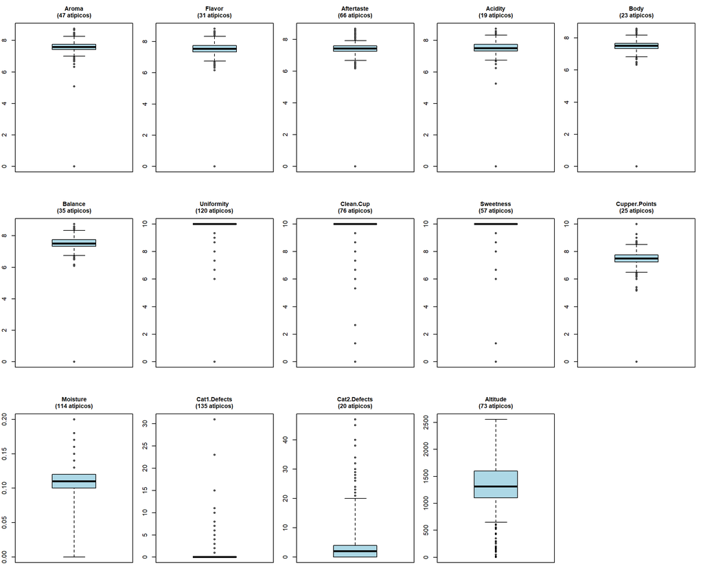

## 3.2. ¿Amerita transformar variables antes de PCA?

> **Teoría — transformación de Yeo-Johnson.** Generaliza Box-Cox para valores ≥ 0:
> $$y(\lambda) =
> \begin{cases} \dfrac{(x+1)^{\lambda}-1}{\lambda}, & \lambda \neq 0
> \\ \ln(x+1), & \lambda = 0 \end{cases}$$
> $\lambda = 1$ equivale a no transformar; se estima por máxima verosimilitud.

```r
yeojohnson_transform <- function(x, lambda) {
  if (lambda != 0) ((x + 1)^lambda - 1) / lambda else log(x + 1)
}
yeojohnson_loglik <- function(lambda, x) {
  y <- yeojohnson_transform(x, lambda)
  -length(x) / 2 * log(var(y)) + (lambda - 1) * sum(log(x + 1))
}
yeojohnson_fit <- function(x) {
  optimize(yeojohnson_loglik, interval = c(-5, 5), x = x, maximum = TRUE)$maximum
}

lambdas_todas <- sapply(datos, yeojohnson_fit)
round(lambdas_todas, 3)
```

```
##                Aroma               Flavor           Aftertaste
##                4.387                3.978                4.050
##              Acidity                 Body              Balance
##                4.055                4.261                3.545
##           Uniformity            Clean.Cup            Sweetness
##                5.000                5.000                5.000
##        Cupper.Points             Moisture Category.One.Defects
##                3.072                5.000               -5.000
## Category.Two.Defects altitude_mean_meters
##               -0.217                1.311
```

```r
lambdas <- sapply(datos[c("Moisture", "Category.One.Defects", "Category.Two.Defects")],
                  yeojohnson_fit)
round(lambdas, 3)
```

```
##             Moisture Category.One.Defects Category.Two.Defects
##                5.000               -5.000               -0.217
```

`Moisture` y `Category.One.Defects` empujan $\lambda$ hasta el borde del intervalo ($\pm 5$): no convergen. Son **infladas en cero** y se excluyen del análisis principal. Solo `Category.Two.Defects` tiene un ajuste estable (λ ≈ −0.22).

```r
pca_referencia <- prcomp(datos, center = TRUE, scale. = TRUE)

datos_transformados <- datos
datos_transformados$Category.Two.Defects <-
  yeojohnson_transform(datos$Category.Two.Defects, lambdas["Category.Two.Defects"])
```

# 4. Matriz de covarianza

```r
S <- cov(datos_transformados)
signif(S, 3)
```

```
##                        Aroma   Flavor Aftertaste  Acidity     Body  Balance
## Aroma                 0.1490  0.13000    0.12500  0.11200  0.10300  0.11900
## Flavor                0.1300  0.16400    0.14800  0.13200  0.11700  0.13800
## Aftertaste            0.1250  0.14800    0.16700  0.12700  0.11800  0.14100
## Acidity               0.1120  0.13200    0.12700  0.15000  0.10800  0.12200
## Body                  0.1030  0.11700    0.11800  0.10800  0.13100  0.12100
## Balance               0.1190  0.13800    0.14100  0.12200  0.12100  0.17400
## Uniformity            0.0870  0.09900    0.10100  0.09290  0.08400  0.10200
## Clean.Cup             0.1160  0.14300    0.14500  0.10800  0.09910  0.13800
## Sweetness             0.0806  0.09210    0.09190  0.08150  0.07770  0.08960
## Cupper.Points         0.1320  0.15800    0.15800  0.13500  0.12600  0.15400
## Moisture             -0.0018 -0.00237   -0.00304 -0.00192 -0.00301 -0.00403
## Category.One.Defects -0.0576 -0.03840   -0.05970 -0.04510 -0.01630 -0.04680
## Category.Two.Defects -0.0369 -0.04270   -0.05030 -0.03120 -0.02720 -0.04490
## altitude_mean_meters 27.2000 26.50000   26.30000 32.40000 18.30000 28.20000
##                      Uniformity Clean.Cup Sweetness Cupper.Points  Moisture
## Aroma                  0.087000    0.1160  0.080600       0.13200 -0.001800
## Flavor                 0.099000    0.1430  0.092100       0.15800 -0.002370
## Aftertaste             0.101000    0.1450  0.091900       0.15800 -0.003040
## Acidity                0.092900    0.1080  0.081500       0.13500 -0.001920
## Body                   0.084000    0.0991  0.077700       0.12600 -0.003010
## Balance                0.102000    0.1380  0.089600       0.15400 -0.004030
## Uniformity             0.280000    0.2090  0.156000       0.10300 -0.000418
## Clean.Cup              0.209000    0.6340  0.224000       0.15400 -0.001400
## Sweetness              0.156000    0.2240  0.263000       0.09220  0.000306
## Cupper.Points          0.103000    0.1540  0.092200       0.22300 -0.003880
## Moisture              -0.000418   -0.0014  0.000306      -0.00388  0.002010
## Category.One.Defects  -0.108000   -0.1900 -0.024300      -0.04080  0.005830
## Category.Two.Defects  -0.026100   -0.0792 -0.010300      -0.04930  0.005400
## altitude_mean_meters   9.140000   15.2000  2.060000      29.40000  0.043800
##                      Category.One.Defects Category.Two.Defects
## Aroma                            -0.05760              -0.0369
## Flavor                           -0.03840              -0.0427
## Aftertaste                       -0.05970              -0.0503
## Acidity                          -0.04510              -0.0312
## Body                             -0.01630              -0.0272
## Balance                          -0.04680              -0.0449
## Uniformity                       -0.10800              -0.0261
## Clean.Cup                        -0.19000              -0.0792
## Sweetness                        -0.02430              -0.0103
## Cupper.Points                    -0.04080              -0.0493
## Moisture                          0.00583               0.0054
## Category.One.Defects              3.52000               0.2410
## Category.Two.Defects              0.24100               0.4670
## altitude_mean_meters            -58.90000              23.0000
##                      altitude_mean_meters
## Aroma                            2.72e+01
## Flavor                           2.65e+01
## Aftertaste                       2.63e+01
## Acidity                          3.24e+01
## Body                             1.83e+01
## Balance                          2.82e+01
## Uniformity                       9.14e+00
## Clean.Cup                        1.52e+01
## Sweetness                        2.06e+00
## Cupper.Points                    2.94e+01
## Moisture                         4.38e-02
## Category.One.Defects            -5.89e+01
## Category.Two.Defects             2.30e+01
## altitude_mean_meters             1.75e+05
```

```r
varianza_total <- sum(diag(S))
cat("Varianza total (traza de S):", varianza_total, "\n")
```

```
## Varianza total (traza de S): 174662.4
```

```r
cat("  -> dominada por altitude_mean_meters:", round(S["altitude_mean_meters","altitude_mean_meters"], 0), "\n")
```

```
##   -> dominada por altitude_mean_meters: 174656
```

```r
cat("  -> razón para estandarizar antes de PCA.\n")
```

```
##   -> razón para estandarizar antes de PCA.
```

# 5. PCA — 8 variables + YJ selectivo

**Decisión: excluir 6 variables del análisis principal** — 3 por inflación de ceros y 3 por inflación de máximos. Ambos patrones impiden que YJ corrija la distribución.

**Variables con inflación de ceros (se excluyen):**

1. **`Moisture` y `Category.One.Defects` — YJ no converge.** Ambas tienen una mezcla de pico en cero más cola continua (174 lotes con `Moisture = 0`; > 80 % con `Cat1 = 0`). La distribución bimodal no es corregible con una transformación monótona de potencia.
2. **`Category.Two.Defects`** — aunque converge (λ ≈ −0.22), se excluye por coherencia con las otras dos variables de defectos y porque los outliers extremos en Cat1/Cat2 dominaban PC3 completo (cargas ≈ 0.54 y 0.65, valores de Mahalanobis > 300).
3. **`Moisture = 0` son faltantes codificados.** UMAP aisló esos 174 lotes en un grupo separado — un valor físicamente imposible (el café retiene 9–13 % de humedad). Incluirlos es un artefacto de calidad de datos.

**Variables con inflación de máximos — “pegged at 10” (se excluyen):**

4. **`Sweetness`, `Uniformity`, `Clean.Cup`** — el 94.7 %, 88.8 % y 92.9 % de los lotes tienen exactamente el valor 10 (perfecto). En café de especialidad, estas tres métricas de control de consistencia se saturan: casi todos los lotes aprobados pasan con la puntuación máxima. El resultado es idéntico al problema de Moisture: una distribución con un pico masivo en un valor (10 en lugar de 0) que YJ no puede normalizar. En el espacio PCA, los ~57 lotes con Sweetness < 10 formaban un “riel” lineal separado de los 1.013 lotes con Sweetness = 10 — causando los patrones lineales observados.

**Consecuencia:** se retienen **8 variables** — los 6 atributos sensoriales que realmente discriminan entre lotes (Aroma, Flavor, Aftertaste, Acidity, Body, Balance), más Cupper.Points (juicio holístico del catador) y altitude_mean_meters (variable geográfica). YJ se aplica selectivamente solo donde |sesgo| > 1.

```r
# Se excluyen 6 variables: 3 con inflación de ceros + 3 con inflación de máximos (>88% en valor 10)
vars_8 <- setdiff(names(datos),
                  c("Category.One.Defects", "Category.Two.Defects", "Moisture",
                    "Sweetness", "Uniformity", "Clean.Cup"))
datos_t <- datos[, vars_8]

cat("Variables en el análisis principal (8):\n")
```

```
## Variables en el análisis principal (8):
```

```r
print(names(datos_t))
```

```
## [1] "Aroma"                "Flavor"               "Aftertaste"
## [4] "Acidity"              "Body"                 "Balance"
## [7] "Cupper.Points"        "altitude_mean_meters"
```

```r
# Verificar fracción con valor == 10 (debe ser 0 para las 8 variables restantes)
frac10 <- sapply(datos_t, function(x) mean(x == 10))
cat("\nFracción con valor == 10 (debe ser ~0 para todas):\n")
```

```
##
## Fracción con valor == 10 (debe ser ~0 para todas):
```

```r
print(round(frac10, 3))
```

```
##                Aroma               Flavor           Aftertaste
##                0.000                0.000                0.000
##              Acidity                 Body              Balance
##                0.000                0.000                0.000
##        Cupper.Points altitude_mean_meters
##                0.001                0.000
```

```r
library(car)
skew <- function(x) mean((x - mean(x))^3) / sd(x)^3

skew_pre <- sapply(datos_t, skew)
cat("Skewness por variable (antes de cualquier transformación):\n")
```

```
## Skewness por variable (antes de cualquier transformación):
```

```r
print(round(skew_pre, 3))
```

```
##                Aroma               Flavor           Aftertaste
##               -7.218               -6.041               -5.636
##              Acidity                 Body              Balance
##               -6.902               -8.231               -5.405
##        Cupper.Points altitude_mean_meters
##               -3.838               -0.827
```

```r
# Solo transformar variables con sesgo fuerte (|skewness| > 1)
vars_transformar <- names(skew_pre[abs(skew_pre) > 1])
vars_sin_transformar <- setdiff(names(skew_pre), vars_transformar)

cat("\nVariables con |sesgo| > 1 → se aplica Yeo-Johnson:\n", vars_transformar, "\n")
```

```
##
## Variables con |sesgo| > 1 → se aplica Yeo-Johnson:
##  Aroma Flavor Aftertaste Acidity Body Balance Cupper.Points
```

```r
cat("Variables con sesgo suave → se dejan sin transformar:\n", vars_sin_transformar, "\n")
```

```
## Variables con sesgo suave → se dejan sin transformar:
##  altitude_mean_meters
```

```r
datos_t_sin_yj <- datos_t

if (length(vars_transformar) > 0) {
  pt_sel <- powerTransform(datos_t[, vars_transformar, drop = FALSE], family = "yjPower")
  lambdas_sel <- coef(pt_sel, round = FALSE)
  cat("\nLambdas Yeo-Johnson (solo variables transformadas):\n")
  print(round(lambdas_sel, 3))
  for (v in vars_transformar) {
    datos_t[[v]] <- yjPower(datos_t[[v]], lambdas_sel[v])
  }
}
```

```
##
## Lambdas Yeo-Johnson (solo variables transformadas):
##         Aroma        Flavor    Aftertaste       Acidity          Body
##         3.590         2.739         2.619         3.291         3.079
##       Balance Cupper.Points
##         2.295         2.177
```

```r
cat("\nSkewness ANTES (solo vars. transformadas):\n")
```

```
##
## Skewness ANTES (solo vars. transformadas):
```

```r
print(round(sapply(datos_t_sin_yj[, vars_transformar, drop=FALSE], skew), 3))
```

```
##         Aroma        Flavor    Aftertaste       Acidity          Body
##        -7.218        -6.041        -5.636        -6.902        -8.231
##       Balance Cupper.Points
##        -5.405        -3.838
```

```r
cat("\nSkewness DESPUES:\n")
```

```
##
## Skewness DESPUES:
```

```r
print(round(sapply(datos_t[, vars_transformar, drop=FALSE], skew), 3))
```

```
##         Aroma        Flavor    Aftertaste       Acidity          Body
##        -0.119        -0.474        -0.584        -0.122        -0.400
##       Balance Cupper.Points
##        -0.663        -0.424
```

```r
cat("\nSkewness variables NO transformadas (referencia):\n")
```

```
##
## Skewness variables NO transformadas (referencia):
```

```r
print(round(sapply(datos_t[, vars_sin_transformar, drop=FALSE], skew), 3))
```

```
## altitude_mean_meters
##               -0.827
```

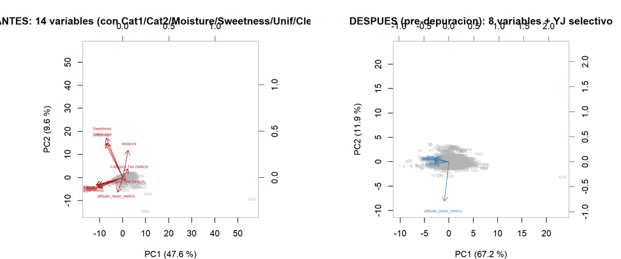

```r
pca_14 <- prcomp(datos_transformados, center = TRUE, scale. = TRUE)

var14 <- round(summary(pca_14)$importance[2, 1:2] * 100, 1)
# Nota: en este punto datos_t tiene YJ aplicado pero los atípicos AÚN NO se han
# retirado (se retiran en la sección 5b). Este gráfico muestra el efecto de la
# selección de variables; la depuración de atípicos se muestra en sección 5b.
pca_despues_comp <- prcomp(datos_t, center = TRUE, scale. = TRUE)
var8  <- round(summary(pca_despues_comp)$importance[2, 1:2] * 100, 1)

par(mfrow = c(1, 2), mar = c(4, 4, 3, 1))
biplot(pca_14, scale = 0, cex = 0.45, col = c("gray70", "firebrick"),
       xlab = paste0("PC1 (", var14[1], " %)"),
       ylab = paste0("PC2 (", var14[2], " %)"),
       main = "ANTES: 14 variables (con Cat1/Cat2/Moisture/Sweetness/Unif/CleanCup)")
biplot(pca_despues_comp, scale = 0, cex = 0.45, col = c("gray70", "steelblue"),
       xlab = paste0("PC1 (", var8[1], " %)"),
       ylab = paste0("PC2 (", var8[2], " %)"),
       main = "DESPUES (pre-depuracion): 8 variables + YJ selectivo")
```

# 5b. Atípicos multivariados — detección, caracterización y depuración

> **Flujo:** (1) PCA exploratorio con todos los lotes → (2) identificar atípicos por distancia de Mahalanobis vía scores → (3) caracterizar qué tienen en común → (4) retirarlos y reportarlos → (5) PCA final sobre datos limpios.

```r
pca_prelim <- prcomp(datos_t, center = TRUE, scale. = TRUE)

# Mahalanobis via scores PCA: numéricamente estable (evita cov singular post-YJ)
dm2_prelim <- rowSums((pca_prelim$x / pca_prelim$sdev)^2)
umbral_chi2 <- qchisq(0.975, df = ncol(datos_t))

idx_atipicos <- which(dm2_prelim > umbral_chi2)
cat("Umbral chi² al 97.5% (p =", ncol(datos_t), "):", round(umbral_chi2, 1), "\n")
```

```
## Umbral chi² al 97.5% (p = 8 ): 17.5
```

```r
cat("Lotes atípicos multivariados:", length(idx_atipicos),
    sprintf("(%.1f%% del total)\n", length(idx_atipicos) / nrow(datos_t) * 100))
```

```
## Lotes atípicos multivariados: 404 (37.8% del total)
```

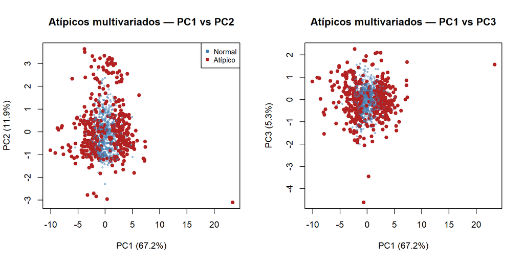

```r
par(mfrow = c(1, 2))
# PC1 vs PC2
plot(pca_prelim$x[, 1], pca_prelim$x[, 2],
     col = ifelse(dm2_prelim > umbral_chi2, "firebrick", adjustcolor("steelblue", 0.4)),
     pch = 19, cex = ifelse(dm2_prelim > umbral_chi2, 0.9, 0.5),
     xlab = paste0("PC1 (", round(pca_prelim$sdev[1]^2/sum(pca_prelim$sdev^2)*100,1), "%)"),
     ylab = paste0("PC2 (", round(pca_prelim$sdev[2]^2/sum(pca_prelim$sdev^2)*100,1), "%)"),
     main = "Atípicos multivariados — PC1 vs PC2")
legend("topright", legend = c("Normal", "Atípico"), pch = 19,
       col = c("steelblue", "firebrick"), cex = 0.8)

# PC1 vs PC3
plot(pca_prelim$x[, 1], pca_prelim$x[, 3],
     col = ifelse(dm2_prelim > umbral_chi2, "firebrick", adjustcolor("steelblue", 0.4)),
     pch = 19, cex = ifelse(dm2_prelim > umbral_chi2, 0.9, 0.5),
     xlab = paste0("PC1 (", round(pca_prelim$sdev[1]^2/sum(pca_prelim$sdev^2)*100,1), "%)"),
     ylab = paste0("PC3 (", round(pca_prelim$sdev[3]^2/sum(pca_prelim$sdev^2)*100,1), "%)"),
     main = "Atípicos multivariados — PC1 vs PC3")
```

```r
# Qué tienen en común los atípicos: comparar sus medias con el resto
vars_orig_11 <- c("Aroma","Sabor","Retrogusto","Acidez","Cuerpo","Balance",
                  "Uniformidad","Taza.Limpia","Dulzura","Puntaje.Catador","Altitud")

# Reconstruir datos originales en la escala pre-transformación para inspección
datos_orig_11 <- datos_t_sin_yj   # antes de YJ selectivo

cat("=== Medias de los atípicos vs. el resto ===\n")
```

```
## === Medias de los atípicos vs. el resto ===
```

```r
comp <- rbind(
  Atipicos = round(colMeans(datos_orig_11[idx_atipicos, , drop=FALSE]), 3),
  Resto    = round(colMeans(datos_orig_11[-idx_atipicos, , drop=FALSE]), 3)
)
print(comp)
```

```
##          Aroma Flavor Aftertaste Acidity  Body Balance Cupper.Points
## Atipicos 7.548  7.490       7.36   7.511 7.497   7.490         7.454
## Resto    7.583  7.535       7.41   7.537 7.509   7.518         7.503
##          altitude_mean_meters
## Atipicos             1238.266
## Resto                1344.645
```

```r
# Revisar el dataset original para detectar patrón
datos_atipicos_raw <- data_f[idx_atipicos, c("Moisture","Category.One.Defects",
                                               "Category.Two.Defects","altitude_mean_meters",
                                               "Country.of.Origin")]
cat("\n--- Distribución de Moisture en atípicos ---\n")
```

```
##
## --- Distribución de Moisture en atípicos ---
```

```r
print(table(round(datos_atipicos_raw$Moisture, 1)))
```

```
##
##   0 0.1 0.2
##  78 321   5
```

```r
cat("\nPaíses de origen de los atípicos:\n")
```

```
##
## Países de origen de los atípicos:
```

```r
print(sort(table(datos_atipicos_raw$Country.of.Origin), decreasing=TRUE)[1:10])
```

```
##
##     Mexico  Guatemala   Colombia     Taiwan     Brazil   Ethiopia Costa Rica
##         87         49         47         33         32         24         22
##   Honduras      Kenya  Nicaragua
##         17         13          9
```

```r
cat("=== REPORTE DE DEPURACIÓN ===\n")
```

```
## === REPORTE DE DEPURACIÓN ===
```

```r
cat("Lotes totales antes de depuración:", nrow(datos_t), "\n")
```

```
## Lotes totales antes de depuración: 1070
```

```r
cat("Lotes atípicos identificados (d²_M > chi²_0.975):", length(idx_atipicos), "\n")
```

```
## Lotes atípicos identificados (d²_M > chi²_0.975): 404
```

```r
cat("Fracción con Moisture = 0 entre atípicos:",
    round(mean(datos_atipicos_raw$Moisture == 0) * 100, 1), "%\n")
```

```
## Fracción con Moisture = 0 entre atípicos: 16.3 %
```

```r
cat("Lotes retenidos para análisis final:", nrow(datos_t) - length(idx_atipicos), "\n")
```

```
## Lotes retenidos para análisis final: 666
```

```r
# Retirar atípicos — pasada única sobre el PCA exploratorio.
# El umbral chi²_0.975 marca por definición el 2.5% más extremo de cualquier
# distribución; iterar hasta cero vaciaría los datos (~86% de remoción en pruebas).
# La pasada única retira los casos genuinamente problemáticos; los ~16 residuales
# que quedan (~2.5% de 666) son el comportamiento estadístico esperado del test.
datos_limpio <- datos_t[-idx_atipicos, ]

cat(sprintf("Lotes retirados: %d de %d (%.1f%%)\n",
            length(idx_atipicos), nrow(datos_t),
            length(idx_atipicos) / nrow(datos_t) * 100))
```

```
## Lotes retirados: 404 de 1070 (37.8%)
```

```r
# Eliminar columnas con varianza cero (constantes tras la depuración)
vars_var_cero <- names(which(apply(datos_limpio, 2, var) == 0))
if (length(vars_var_cero) > 0) {
  cat("Variables con varianza cero retiradas:", vars_var_cero, "\n")
  datos_limpio <- datos_limpio[, apply(datos_limpio, 2, var) > 0]
}
cat("Dimensiones de la matriz limpia:", nrow(datos_limpio), "×", ncol(datos_limpio), "\n")
```

```
## Dimensiones de la matriz limpia: 666 × 8
```

```r
Z <- scale(datos_limpio)
round(colMeans(Z), 12)
```

```
##                Aroma               Flavor           Aftertaste
##                    0                    0                    0
##              Acidity                 Body              Balance
##                    0                    0                    0
##        Cupper.Points altitude_mean_meters
##                    0                    0
```

```r
round(apply(Z, 2, var), 3)
```

```
##                Aroma               Flavor           Aftertaste
##                    1                    1                    1
##              Acidity                 Body              Balance
##                    1                    1                    1
##        Cupper.Points altitude_mean_meters
##                    1                    1
```

```r
# PCA final sobre datos sin atípicos
pca <- prcomp(datos_limpio, center = TRUE, scale. = TRUE)
cat("PCA final: datos limpios (", nrow(datos_limpio), "lotes ×", ncol(datos_limpio), "variables)\n")
```

```
## PCA final: datos limpios ( 666 lotes × 8 variables)
```

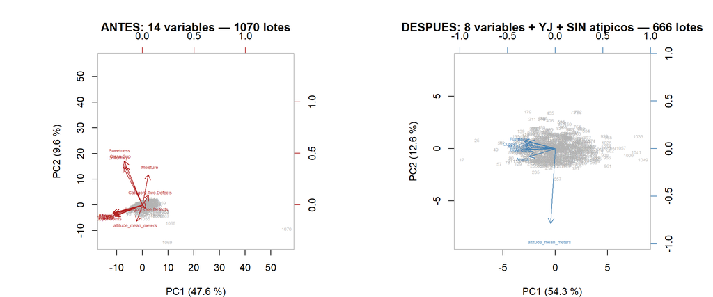

```r
# Comparación definitiva: 14 variables vs. 8 variables + YJ + SIN atípicos
var14_f <- round(summary(pca_14)$importance[2, 1:2] * 100, 1)
var8_f  <- round(summary(pca)$importance[2, 1:2] * 100, 1)

par(mfrow = c(1, 2), mar = c(4, 4, 3.5, 1))
biplot(pca_14, scale = 0, cex = 0.45, col = c("gray70", "firebrick"),
       xlab = paste0("PC1 (", var14_f[1], " %)"),
       ylab = paste0("PC2 (", var14_f[2], " %)"),
       main = paste0("ANTES: 14 variables — ", nrow(datos_transformados), " lotes"))
biplot(pca, scale = 0, cex = 0.45, col = c("gray70", "steelblue"),
       xlab = paste0("PC1 (", var8_f[1], " %)"),
       ylab = paste0("PC2 (", var8_f[2], " %)"),
       main = paste0("DESPUES: 8 variables + YJ + SIN atipicos — ", nrow(datos_limpio), " lotes"))
```

# 6. Selección del número de componentes

```r
summary(pca)
```

```
## Importance of components:
##                           PC1    PC2     PC3    PC4     PC5     PC6     PC7
## Standard deviation     2.0835 1.0022 0.84098 0.7299 0.69121 0.58605 0.58217
## Proportion of Variance 0.5426 0.1255 0.08841 0.0666 0.05972 0.04293 0.04236
## Cumulative Proportion  0.5426 0.6682 0.75656 0.8232 0.88289 0.92582 0.96818
##                            PC8
## Standard deviation     0.50452
## Proportion of Variance 0.03182
## Cumulative Proportion  1.00000
```

```r
pca$sdev^2
```

```
## [1] 4.3408968 1.0043470 0.7072551 0.5328220 0.4777654 0.3434574 0.3389194
## [8] 0.2545369
```

```r
cat("Componentes con lambda > 1 (Kaiser):", sum(pca$sdev^2 > 1), "\n")
```

```
## Componentes con lambda > 1 (Kaiser): 2
```

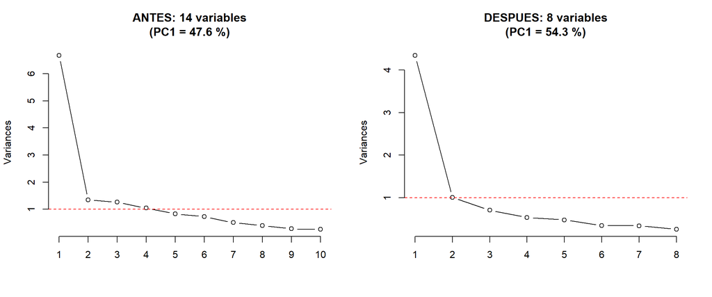

```r
par(mfrow = c(1, 2))
screeplot(pca_14, type = "lines",
          main = paste0("ANTES: 14 variables\n(PC1 = ",
                        round(pca_14$sdev[1]^2 / sum(pca_14$sdev^2) * 100, 1), " %)"))
abline(h = 1, lty = 2, col = "red")

screeplot(pca, type = "lines",
          main = paste0("DESPUES: 8 variables\n(PC1 = ",
                        round(pca$sdev[1]^2 / sum(pca$sdev^2) * 100, 1), " %)"))
abline(h = 1, lty = 2, col = "red")
```

# 7. Verificación: matriz de dispersión de scores

> **Teoría.** $\operatorname{Cov}(Z_i, Z_j) = 0$ para $i \neq j$: en la matriz de dispersión **no debe verse correlación lineal**. Lo que se busca es: agrupamientos, patrones y atípicos.

```r
head(pca$x)
```

```
##          PC1         PC2         PC3         PC4        PC5        PC6
## 17 -8.936610 -1.03650527 -0.24929645  0.12869531 -0.2620022  0.8210078
## 25 -7.478287  0.82719333  0.04344595  0.92245121 -0.2673770  0.1804227
## 49 -5.668671 -0.05686775  0.77069881  0.01679051  0.7912599 -0.7452882
## 57 -5.358441 -1.45925490 -0.44077775 -1.03407732 -0.6936226 -0.1497108
## 58 -5.261558  0.55327026 -0.05936791 -1.44634884  0.7041461 -0.3474815
## 65 -5.043770  0.63480696  1.05286473  0.44122387 -0.6595152 -0.8831620
##            PC7        PC8
## 17  0.26086026  0.1273102
## 25  0.73668993  0.7900175
## 49 -0.43437344 -0.6011813
## 57 -1.24992116 -0.3811994
## 58  0.03664691 -0.1085310
## 65  0.15524995  0.4569524
```

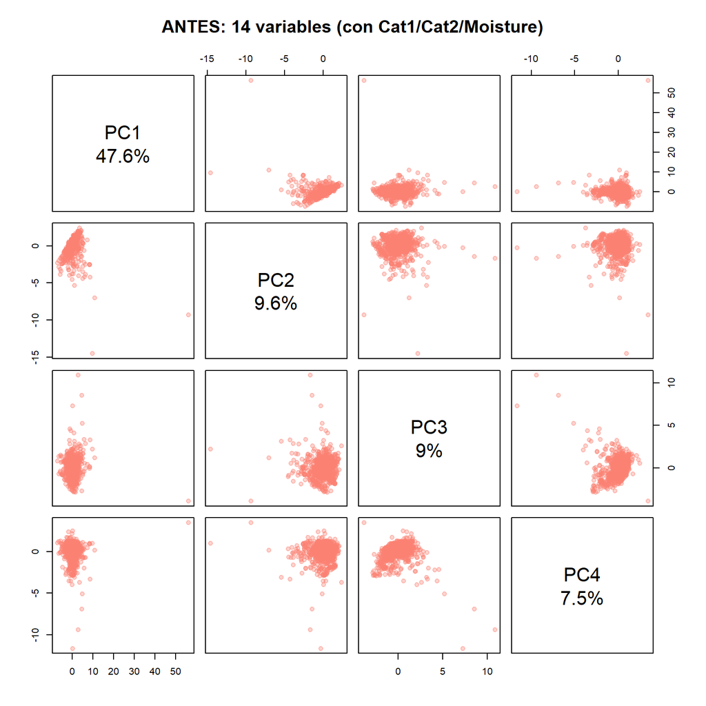

```r
k <- 4
pairs(pca_14$x[, 1:k],
      main = "ANTES: 14 variables (con Cat1/Cat2/Moisture)",
      pch = 19,
      col = adjustcolor("salmon", alpha.f = 0.35),
      labels = paste0("PC", 1:k, "\n",
                      round(pca_14$sdev[1:k]^2/sum(pca_14$sdev^2)*100,1), "%"))
```

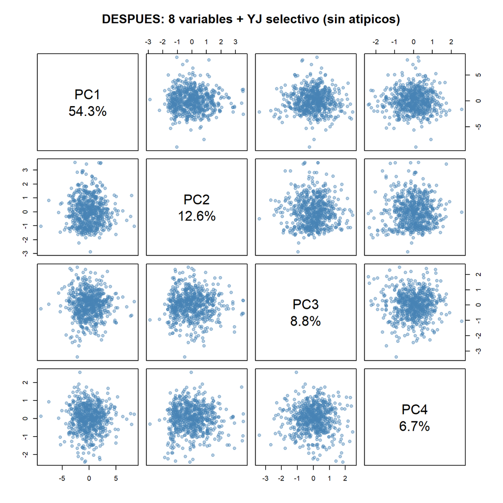

```r
k <- 4
pairs(pca$x[, 1:k],
      main = "DESPUES: 8 variables + YJ selectivo (sin atipicos)",
      pch = 19,
      col = adjustcolor("steelblue", alpha.f = 0.4),
      labels = paste0("PC", 1:k, "\n",
                      round(pca$sdev[1:k]^2/sum(pca$sdev^2)*100,1), "%"))
```

**Comparación:** ANTES, PC3 muestra puntos extremos muy alejados (lotes con 23–31 defectos primarios). DESPUÉS, la nube es compacta y sin tendencias lineales en ningún par. **Verificación superada.**

```r
idx_pc1 <- order(pca$x[, 1], decreasing = TRUE)[1:2]
idx_pc3 <- order(pca$x[, 3], decreasing = TRUE)[1:2]
idx_pc4 <- order(pca$x[, 4])[1:2]
datos[-idx_atipicos, ][unique(c(idx_pc1, idx_pc3, idx_pc4)), ]
```

|  | Aroma | Flavor | Aftertaste | Acidity | Body | Balance | Uniformity | Clean.Cup | Sweetness | Cupper.Points | Moisture | Category.One.Defects | Category.Two.Defects | altitude_mean_meters |
| --- | --- | --- | --- | --- | --- | --- | --- | --- | --- | --- | --- | --- | --- | --- |
| 1049 | 7.08 | 6.75 | 6.58 | 7.00 | 7.00 | 6.75 | 8.67 | 8.67 | 10 | 6.42 | 0.17 | 0 | 6 | 1500 |
| 1033 | 6.83 | 6.83 | 6.83 | 6.75 | 6.92 | 6.92 | 9.33 | 10.00 | 10 | 6.83 | 0.10 | 0 | 1 | 825 |
| 242 | 8.00 | 7.92 | 7.58 | 7.75 | 7.33 | 7.50 | 10.00 | 10.00 | 10 | 7.67 | 0.12 | 0 | 0 | 1400 |
| 133 | 8.00 | 7.92 | 7.42 | 8.08 | 7.50 | 7.67 | 10.00 | 10.00 | 10 | 7.92 | 0.12 | 0 | 0 | 1350 |
| 599 | 8.00 | 7.75 | 7.33 | 7.33 | 7.08 | 7.67 | 9.33 | 10.00 | 10 | 7.83 | 0.11 | 0 | 0 | 1300 |
| 439 | 8.08 | 7.50 | 7.67 | 7.42 | 7.33 | 7.50 | 10.00 | 10.00 | 10 | 7.42 | 0.00 | 0 | 0 | 1600 |

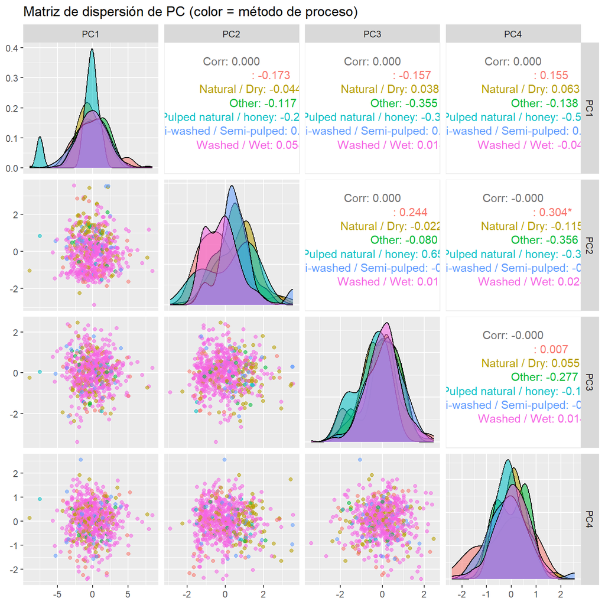

```r
library(GGally)

pca_scores <- as.data.frame(pca$x[, 1:k])
pca_scores$Processing.Method <- data_f[as.integer(rownames(datos_limpio)), "Processing.Method"]

ggpairs(pca_scores,
        columns = 1:k,
        aes(color = Processing.Method, alpha = 0.5)) +
  ggtitle("Matriz de dispersión de PC (color = método de proceso)")
```